# IODS course project

## 3 | Regression Model

Now I will proceed with the 3rd point of the assignment. As explanatory variables, I have chosen: attitude, deep and stra. The outcome variable is the exam points. Since the stra and the deep variables are not significant, we remove them from the model. Interpretation of the results: We can see that the attitude can predict the exam points. Since the Estimate is positive, it means that it is a positive correlation, so the more attitutde the student has, the more points their get.

```r
# create a regression model with multiple explanatory variables
my_model <- lm(points ~ attitude + stra + deep, data = lrn14)

# print out a summary of the model
summary(my_model)
```

```
##
## Call:
## lm(formula = points ~ attitude + stra + deep, data = lrn14)
##
## Residuals:
##      Min       1Q   Median       3Q      Max
## -17.5239  -3.4276   0.5474   3.8220  11.5112
##
## Coefficients:
##             Estimate Std. Error t value Pr(>|t|)
## (Intercept)  11.3915     3.4077   3.343  0.00103 **
## attitude      3.5254     0.5683   6.203 4.44e-09 ***
## stra          0.9621     0.5367   1.793  0.07489 .
## deep         -0.7492     0.7507  -0.998  0.31974
## ---
## Signif. codes:  0 '***' 0.001 '**' 0.01 '*' 0.05 '.' 0.1 ' ' 1
##
## Residual standard error: 5.289 on 162 degrees of freedom
## Multiple R-squared:  0.2097, Adjusted R-squared:  0.195
## F-statistic: 14.33 on 3 and 162 DF,  p-value: 2.521e-08
```

```r
#create the new model without the non-significant predictors.
my_model2 <- lm(points ~ attitude, data = lrn14)
summary(my_model2)
```

```
##
## Call:
## lm(formula = points ~ attitude, data = lrn14)
##
## Residuals:
##      Min       1Q   Median       3Q      Max
## -16.9763  -3.2119   0.4339   4.1534  10.6645
##
## Coefficients:
##             Estimate Std. Error t value Pr(>|t|)
## (Intercept)  11.6372     1.8303   6.358 1.95e-09 ***
## attitude      3.5255     0.5674   6.214 4.12e-09 ***
## ---
## Signif. codes:  0 '***' 0.001 '**' 0.01 '*' 0.05 '.' 0.1 ' ' 1
##
## Residual standard error: 5.32 on 164 degrees of freedom
## Multiple R-squared:  0.1906, Adjusted R-squared:  0.1856
## F-statistic: 38.61 on 1 and 164 DF,  p-value: 4.119e-09
```

Finally, we will produce the diagnostic plots. The assumptions of the model are (1) Linear relationship between predictors and outcome, (2) Independence of residuals, (3) Normal distribution of residuals, (4) Equal variance of residuals. The Residuals vs Fitted plot gives us information about the equal variance of the residuals. We can see that this assumption is acomplished, since the two lines are really similar. The Q-Q plot gives us information about the normal distirbution of the residuals. Again, we see that the residuals are normally distirbuted. Finally, the Residuals vs Leverage plot gives information about the allows us to identify influential observations in a regression model. We can see that there are not influential points, since there are no observaions falling outside the dashed lines.

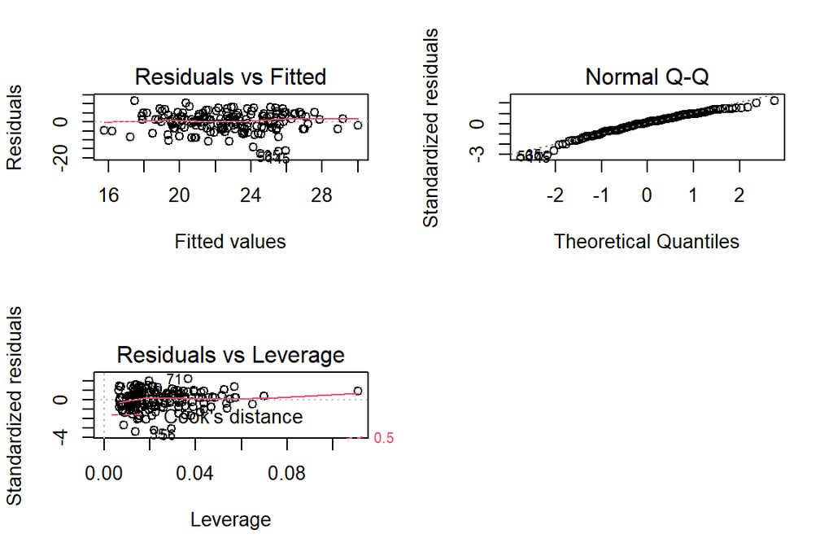

```r
par(mfrow = c(2,2))
plot(my_model, which =c(1,2,5))
```

# Logistic Regression

## 1 | Load input data

```r
library(readr)
alc <- read_csv("C:\\LocalData\\navarret\\IODS\\IODS-project\\data\\create_alc.csv")
str(alc)
```

```
## spc_tbl_ [370 x 35] (S3: spec_tbl_df/tbl_df/tbl/data.frame)
##  $ school    : chr [1:370] "GP" "GP" "GP" "GP" ...
##  $ sex       : chr [1:370] "F" "F" "F" "F" ...
##  $ age       : num [1:370] 18 17 15 15 16 16 16 17 15 15 ...
##  $ address   : chr [1:370] "U" "U" "U" "U" ...
##  $ famsize   : chr [1:370] "GT3" "GT3" "LE3" "GT3" ...
##  $ Pstatus   : chr [1:370] "A" "T" "T" "T" ...
##  $ Medu      : num [1:370] 4 1 1 4 3 4 2 4 3 3 ...
##  $ Fedu      : num [1:370] 4 1 1 2 3 3 2 4 2 4 ...
##  $ Mjob      : chr [1:370] "at_home" "at_home" "at_home" "health" ...
##  $ Fjob      : chr [1:370] "teacher" "other" "other" "services" ...
##  $ reason    : chr [1:370] "course" "course" "other" "home" ...
##  $ guardian  : chr [1:370] "mother" "father" "mother" "mother" ...
##  $ traveltime: num [1:370] 2 1 1 1 1 1 1 2 1 1 ...
##  $ studytime : num [1:370] 2 2 2 3 2 2 2 2 2 2 ...
##  $ schoolsup : chr [1:370] "yes" "no" "yes" "no" ...
##  $ famsup    : chr [1:370] "no" "yes" "no" "yes" ...
##  $ activities: chr [1:370] "no" "no" "no" "yes" ...
##  $ nursery   : chr [1:370] "yes" "no" "yes" "yes" ...
##  $ higher    : chr [1:370] "yes" "yes" "yes" "yes" ...
##  $ internet  : chr [1:370] "no" "yes" "yes" "yes" ...
##  $ romantic  : chr [1:370] "no" "no" "no" "yes" ...
##  $ famrel    : num [1:370] 4 5 4 3 4 5 4 4 4 5 ...
##  $ freetime  : num [1:370] 3 3 3 2 3 4 4 1 2 5 ...
##  $ goout     : num [1:370] 4 3 2 2 2 2 4 4 2 1 ...
##  $ Dalc      : num [1:370] 1 1 2 1 1 1 1 1 1 1 ...
##  $ Walc      : num [1:370] 1 1 3 1 2 2 1 1 1 1 ...
##  $ health    : num [1:370] 3 3 3 5 5 5 3 1 1 5 ...
##  $ failures  : num [1:370] 0 0 2 0 0 0 0 0 0 0 ...
##  $ paid      : chr [1:370] "no" "no" "yes" "yes" ...
##  $ absences  : num [1:370] 5 3 8 1 2 8 0 4 0 0 ...
##  $ G1        : num [1:370] 2 7 10 14 8 14 12 8 16 13 ...
##  $ G2        : num [1:370] 8 8 10 14 12 14 12 9 17 14 ...
##  $ G3        : num [1:370] 8 8 11 14 12 14 12 10 18 14 ...
##  $ alc_use   : num [1:370] 1 1 2.5 1 1.5 1.5 1 1 1 1 ...
##  $ high_use  : logi [1:370] FALSE FALSE TRUE FALSE FALSE FALSE ...
##  - attr(*, "spec")=
##   .. cols(
##   ..   school = col_character(),
##   ..   sex = col_character(),
```

[output cut: 20 more lines]

```
##   ..   freetime = col_double(),
##   ..   goout = col_double(),
##   ..   Dalc = col_double(),
##   ..   Walc = col_double(),
##   ..   health = col_double(),
##   ..   failures = col_double(),
##   ..   paid = col_character(),
##   ..   absences = col_double(),
##   ..   G1 = col_double(),
##   ..   G2 = col_double(),
##   ..   G3 = col_double(),
##   ..   alc_use = col_double(),
##   ..   high_use = col_logical()
##   .. )
##  - attr(*, "problems")=<externalptr>
```

```r
dim(alc)
```

```
## [1] 370  35
```

```r
head(alc)
```

```
## # A tibble: 6 x 35
##   school sex     age address famsize Pstatus  Medu  Fedu Mjob     Fjob    reason
##   <chr>  <chr> <dbl> <chr>   <chr>   <chr>   <dbl> <dbl> <chr>    <chr>   <chr>
## 1 GP     F        18 U       GT3     A           4     4 at_home  teacher course
## 2 GP     F        17 U       GT3     T           1     1 at_home  other   course
## 3 GP     F        15 U       LE3     T           1     1 at_home  other   other
## 4 GP     F        15 U       GT3     T           4     2 health   servic~ home
## 5 GP     F        16 U       GT3     T           3     3 other    other   home
## 6 GP     M        16 U       LE3     T           4     3 services other   reput~
## # i 24 more variables: guardian <chr>, traveltime <dbl>, studytime <dbl>,
## #   schoolsup <chr>, famsup <chr>, activities <chr>, nursery <chr>,
## #   higher <chr>, internet <chr>, romantic <chr>, famrel <dbl>, freetime <dbl>,
## #   goout <dbl>, Dalc <dbl>, Walc <dbl>, health <dbl>, failures <dbl>,
## #   paid <chr>, absences <dbl>, G1 <dbl>, G2 <dbl>, G3 <dbl>, alc_use <dbl>,
## #   high_use <lgl>
```

## 2 | Relationships between variables

The purpose of the analysis now is to study the relationships between the variables of our data. We will explore the relationship between high/low alcohol consumption and the following 4 variables: health, absences, G1 and G3. To do it, we will create multiple boxplots. Our hypothesis are the following: * * Lower alcohol use is related with a better health. * Lower alcohol use is related with a smaller rate of school absence. * Lower alcohol use is related with better grades (G1 and G3 variables)

We will start by looking at the distribution of the variables, as well as the correlation between them:

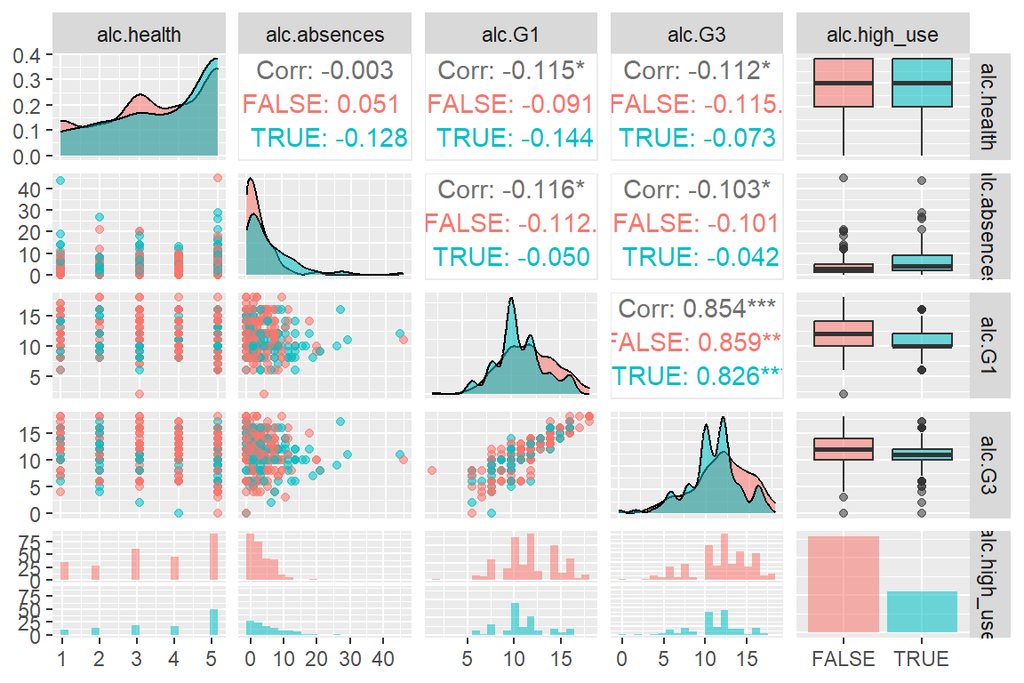

```r
library(ggplot2)
library(GGally)
alc2 <- data.frame(alc$health, alc$absences, alc$G1, alc$G3, alc$high_use)
p <- ggpairs(alc2,mapping = aes(col = alc.high_use, alpha = 0.3), lower = list(combo = wrap("facethist", bins = 20)))
print(p)
```

Now we can look at the boxplots in more detail to see the effect of the consumption of alcohol specfically:

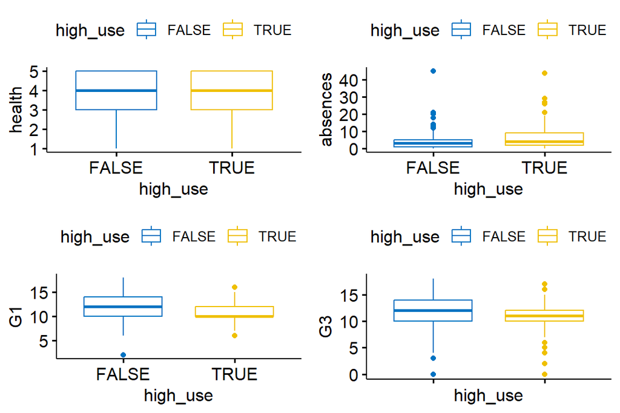

```r
library(ggpubr)

p1 <- ggboxplot(alc, x = "high_use", y = "health",
                 color = "high_use", palette = "jco")
p2 <- ggboxplot(alc, x = "high_use", y = "absences",
                 color = "high_use", palette = "jco")
p3 <- ggboxplot(alc, x = "high_use", y = "G1",
                 color = "high_use", palette = "jco")
p4 <- ggboxplot(alc, x = "high_use", y = "G3",
                 color = "high_use", palette = "jco")

ggarrange(p1, p2, p3, p4 + rremove("x.text"),
          ncol = 2, nrow = 2)
```

And now lets see some cross-tables:

```r
library(dplyr)
alc %>% group_by(high_use) %>% summarise(count = n(), mean_health = mean(health), mean_absences = mean(absences), mean_G1 = mean(G1), mean_G3 = mean(G3))
```

```
## # A tibble: 2 x 6
##   high_use count mean_health mean_absences mean_G1 mean_G3
##   <lgl>    <int>       <dbl>         <dbl>   <dbl>   <dbl>
## 1 FALSE      259        3.49          3.71    11.8    11.8
## 2 TRUE       111        3.73          6.38    10.9    10.9
```

## 3 | Logistic regression

Now we will use logistic regression to statistically explore the relationship between my chosen variables and the binary high/low alcohol consumption variable as the target variable. We will see the summary and coeficients of the model. By looking at this data, we can say that the only variable that was significantly associated with the alcohol consumption was the absences. Then, only our second hypothesis was confirmed.

```r
# find the model with glm()
m <- glm(high_use ~ health + absences + G1 + G3, data = alc, family = "binomial")
# print out a summary of the model
summary(m)
```

```
##
## Call:
## glm(formula = high_use ~ health + absences + G1 + G3, family = "binomial",
##     data = alc)
##
## Deviance Residuals:
##     Min       1Q   Median       3Q      Max
## -2.3382  -0.8270  -0.7147   1.2469   1.9795
##
## Coefficients:
##               Estimate Std. Error z value Pr(>|z|)
## (Intercept) -0.4588189  0.6486882  -0.707 0.479378
## health       0.1118792  0.0866699   1.291 0.196750
## absences     0.0826225  0.0229429   3.601 0.000317 ***
## G1          -0.1041614  0.0824851  -1.263 0.206664
## G3          -0.0006489  0.0669548  -0.010 0.992268
## ---
## Signif. codes:  0 '***' 0.001 '**' 0.01 '*' 0.05 '.' 0.1 ' ' 1
##
## (Dispersion parameter for binomial family taken to be 1)
##
##     Null deviance: 452.04  on 369  degrees of freedom
## Residual deviance: 426.54  on 365  degrees of freedom
## AIC: 436.54
##
## Number of Fisher Scoring iterations: 4
```

```r
# print out the coefficients of the model
coef(m)
```

```
##   (Intercept)        health      absences            G1            G3
## -0.4588189261  0.1118791578  0.0826225009 -0.1041614283 -0.0006488534
```

And now, we will look at the odds ratios and intervals of confidence. Regarding the absences, we can see that those subjects high higher alcohol consumption had a larger number of absences from school (ODDS larger than 1), although the effect is not really high. We can only trust for the absences, since the confidence intervals does not include 1. If it includes 1, we cannot think that the OR is statistically significant.

```r
# compute odds ratios (OR)
OR <- coef(m) %>% exp
# compute confidence intervals (CI)
CI <- confint(m) %>% exp
# print out the odds ratios with their confidence intervals
cbind(OR, CI)
```

```
##                    OR     2.5 %   97.5 %
## (Intercept) 0.6320297 0.1755899 2.249591
## health      1.1183777 0.9453741 1.328993
## absences    1.0861317 1.0405976 1.138721
## G1          0.9010798 0.7651943 1.058841
## G3          0.9993514 0.8776040 1.142445
```

## 4 | Predicitve power of the model

### Predictive power

Refining the model: culling variables that showed no statistical significance Health, G1 and G3 will be dropped, absences remain.

```r
m <- glm(high_use ~ absences, data = alc, family = "binomial")
```

Here, we take the model from before, and based on it calculate the probability that a certain subject is considered as a higher alcohol drinker.

```r
alc$predicted_probabilities <- predict(m, type = "response")

alc <- mutate(alc,prediction  = predicted_probabilities > 0.5)
```

## Comparison of actual values (High use or not) and predicted values.

```r
x<-alc %>% select(absences, high_use, predicted_probabilities, prediction)
x<-table(high_use = x$high_use, prediction = x$prediction)
y<-x
y<-(y/370)*100
print(x)
```

```
##         prediction
## high_use FALSE TRUE
##    FALSE   254    5
##    TRUE    102    9
```

```r
print (y)
```

```
##         prediction
## high_use     FALSE      TRUE
##    FALSE 68.648649  1.351351
##    TRUE  27.567568  2.432432
```

### Penalty function definition

```r
# define a loss function (mean prediction error)
loss_func <- function(class, prob) {
  n_wrong <- abs(class - prob) > 0.5
  mean(n_wrong)
}
```

### Cross validation

```r
# K-fold cross-validation
library(boot)
cv <- cv.glm(data = alc, cost = loss_func, glmfit = m, K = 10)

# average number of wrong predictions in the cross validation
cv$delta[1]
```

```
## [1] 0.2864865
```

The predictors that are looking at now at have a bit higher mean prediction error, but this is not super high.

# Clustering and classification

The topics of this chapter - clustering and classification - are handy and visual tools of exploring statistical data. Clustering means that some points (or observations) of the data are in some sense closer to each other than some other points. In other words, the data points do not comprise a homogeneous sample, but instead, it is somehow clustered.

In general, the clustering methods try to find these clusters (or groups) from the data. One of the most typical clustering methods is called k-means clustering. Also hierarchical clustering methods quite popular, giving tree-like dendrograms as their main output.

As such, clusters are easy to find, but what might be the “right” number of clusters? It is not always clear. And how to give these clusters names and interpretations?

Based on a successful clustering, we may try to classify new observations to these clusters and hence validate the results of clustering. Another way is to use various forms of discriminant analysis, which operates with the (now) known clusters, asking: “what makes the difference(s) between these groups (clusters)?”

In the connection of these methods, we also discuss the topic of distance (or dissimilarity or similarity) measures. There are lots of other measures than just the ordinary Euclidean distance, although it is one of the most important ones. Several discrete and even binary measures exist and are widely used for different purposes in various disciplines.

## 1 | Load input data

We will work with the Boston dataset, which can be found in the MASS package in R. Let’s load it.

```r
# access the MASS package
library(MASS)
# load the data
data("Boston")
```

Now we can look at the structure and dimensions of the data. This dataset has 506 rows and 14 columns, so we can tell that it has 14 variables on it, and 506 observations. The included variables are:

CRIM - per capita crime rate by town ZN - proportion of residential land zoned for lots over 25,000 sq.ft. INDUS - proportion of non-retail business acres per town. CHAS - Charles River dummy variable (1 if tract bounds river; 0 otherwise) NOX - nitric oxides concentration (parts per 10 million) RM - average number of rooms per dwelling AGE - proportion of owner-occupied units built prior to 1940 DIS - weighted distances to five Boston employment centres RAD - index of accessibility to radial highways TAX - full-value property-tax rate per $10,000 PTRATIO - pupil-teacher ratio by town B - 1000(Bk - 0.63)^2 where Bk is the proportion of blacks by town LSTAT - % lower status of the population MEDV - Median value of owner-occupied homes in $1000’s

```r
dim(Boston)
```

```
## [1] 506  14
```

```r
str(Boston)
```

```
## 'data.frame':    506 obs. of  14 variables:
##  $ crim   : num  0.00632 0.02731 0.02729 0.03237 0.06905 ...
##  $ zn     : num  18 0 0 0 0 0 12.5 12.5 12.5 12.5 ...
##  $ indus  : num  2.31 7.07 7.07 2.18 2.18 2.18 7.87 7.87 7.87 7.87 ...
##  $ chas   : int  0 0 0 0 0 0 0 0 0 0 ...
##  $ nox    : num  0.538 0.469 0.469 0.458 0.458 0.458 0.524 0.524 0.524 0.524 ...
##  $ rm     : num  6.58 6.42 7.18 7 7.15 ...
##  $ age    : num  65.2 78.9 61.1 45.8 54.2 58.7 66.6 96.1 100 85.9 ...
##  $ dis    : num  4.09 4.97 4.97 6.06 6.06 ...
##  $ rad    : int  1 2 2 3 3 3 5 5 5 5 ...
##  $ tax    : num  296 242 242 222 222 222 311 311 311 311 ...
##  $ ptratio: num  15.3 17.8 17.8 18.7 18.7 18.7 15.2 15.2 15.2 15.2 ...
##  $ black  : num  397 397 393 395 397 ...
##  $ lstat  : num  4.98 9.14 4.03 2.94 5.33 ...
##  $ medv   : num  24 21.6 34.7 33.4 36.2 28.7 22.9 27.1 16.5 18.9 ...
```

```r
head(Boston)
```

```
##      crim zn indus chas   nox    rm  age    dis rad tax ptratio  black lstat
## 1 0.00632 18  2.31    0 0.538 6.575 65.2 4.0900   1 296    15.3 396.90  4.98
## 2 0.02731  0  7.07    0 0.469 6.421 78.9 4.9671   2 242    17.8 396.90  9.14
## 3 0.02729  0  7.07    0 0.469 7.185 61.1 4.9671   2 242    17.8 392.83  4.03
## 4 0.03237  0  2.18    0 0.458 6.998 45.8 6.0622   3 222    18.7 394.63  2.94
## 5 0.06905  0  2.18    0 0.458 7.147 54.2 6.0622   3 222    18.7 396.90  5.33
## 6 0.02985  0  2.18    0 0.458 6.430 58.7 6.0622   3 222    18.7 394.12  5.21
##   medv
## 1 24.0
## 2 21.6
## 3 34.7
## 4 33.4
## 5 36.2
## 6 28.7
```